# 用 Quarto 写可复现的 Python 分析报告

一个本身就能渲染的 .qmd 教程（scanpy 内置数据，离线可跑）

Published

November 19, 2026

## 1 结论：这个文件是什么、怎么用

`.qmd` = **Markdown 正文 + 可执行代码块 + 顶部 YAML 配置**。`quarto render` 会启动一个 Jupyter kernel，把代码块从上到下跑一遍，再把正文、代码、输出、图一起排成 HTML/PDF/Word。

和 `.ipynb` 相比，三点最关键：

| 维度 | `.qmd` | `.ipynb` |
| --- | --- | --- |
| 文件内容 | 纯文本，只有源码，**不存输出** | JSON，源码和输出（含 base64 图）存在一起 |
| git diff | 逐行可读 | 一改就是几百行 JSON 噪声 |
| 可复现性 | **每次渲染都从头重跑**，不可能出现”输出是旧的” | 输出可能来自乱序执行、早已删掉的单元格 |
| 交互开发 | VS Code / Positron 里可逐块运行 | 原生 |

```bash
cd /home/gao/Utilities/Bioinfo/single_cell_and_spatial/technical_issue
QUARTO_PYTHON=/mnt/ex_8T_SSD/conda_envs/sc_tut_main/bin/python \
  mamba run -p /mnt/ex_8T_SSD/conda_envs/sc_tut_r \
  quarto render quarto_python_reproducible_report_tutorial_20261119.qmd
```

## 2 YAML 头：整份报告的配置

文件最上面 `---` 之间的部分。本文件用到的键：

| 键 | 作用 | 常见取值 |
| --- | --- | --- |
| `format: html:` | 输出格式及其选项 | `html`、`pdf`、`docx`；可以同时写多个 |
| `embed-resources: true` | 打包成单个 HTML | 不开则会多出一个 `*_files/` 目录 |
| `toc` / `number-sections` | 目录、章节编号 | `true` / `false` |
| `jupyter:` | **执行代码用的 kernel 名** | `jupyter kernelspec list` 里列出的名字 |
| `execute:` | 全局执行选项 | `echo`、`warning`、`eval`、`freeze`、`cache` |

## 3 选 kernel = 选 conda 环境

`jupyter: sc_tut_main` 指向 `~/.local/share/jupyter/kernels/sc_tut_main`，它对应 `/mnt/ex_8T_SSD/conda_envs/sc_tut_main` 这个环境。**写错 kernel 名不一定报错**：Quarto 可能退回默认的 `python3`，用另一个环境的包版本跑完整份报告。所以报告里应当打印实际使用的解释器路径：

```python
import sys
print(sys.executable)
```

```
/mnt/ex_8T_SSD/conda_envs/sc_tut_main/bin/python
```

本机已注册的 kernel 有 `sc_tut_main`、`sc_tut_grn`、`sc_tut_spatial`、`sc_tut_traj` 等。做 GRN 的章节要换成 `jupyter: sc_tut_grn`。不同环境不能在同一个 `.qmd` 里混用，一个文件只用一个 kernel。

## 4 代码块与 `#|` 选项

代码块写成 `` ```{python} ``。块内开头以 `#|` 开头的行是**块级选项**，只作用于这一块，会覆盖 YAML 里的全局设置：

[output not shown]

下面开始一个最小但完整的分析示例。先载入包并记录版本：

```python
import numpy as np
import pandas as pd
import scanpy as sc
import matplotlib
from importlib.metadata import version

pd.DataFrame(
    {"version": [version(p) for p in ["scanpy", "anndata", "numpy", "pandas", "matplotlib"]]},
    index=["scanpy", "anndata", "numpy", "pandas", "matplotlib"],
)
```

|  | version |
| --- | --- |
| scanpy | 1.11.5 |
| anndata | 0.12.19 |
| numpy | 2.4.6 |
| pandas | 2.3.3 |
| matplotlib | 3.11.1 |

## 5 参数块与随机种子

把所有”可能要改的数”集中放在一个带 `tags: [parameters]` 的块里。这样渲染时可以用 `-P` 从命令行改，正文和代码都不用动：

```python
seed = 2026          # 随机种子，非零（0 在某些库里会被当成"没给"，见下文）
n_subsample = 300    # 下采样细胞数
```

**随机性必须显式播种，并且要验证”跑两遍结果一样”。** 这里用 `numpy` 新式的 `Generator`，种子作为参数传进去，而不是依赖全局状态：

```python
adata = sc.datasets.pbmc68k_reduced()   # scanpy 自带的 700 细胞示例数据，不需要下载

def subsample(adata, n, seed):
    rng = np.random.default_rng(seed)
    idx = rng.choice(adata.n_obs, size=n, replace=False)
    return adata[np.sort(idx)].copy()

a1 = subsample(adata, n_subsample, seed)
a2 = subsample(adata, n_subsample, seed)
assert (a1.obs_names == a2.obs_names).all(), "同种子两次下采样结果不同"
print(f"同种子两次下采样一致：{a1.n_obs} 个细胞")
```

```
同种子两次下采样一致：300 个细胞
```

**Warning`seed=0` 的坑**

不少库内部写的是 `if seed:` 或 `if self.random_state:`，0 是 falsy，**等于没有播种**，而且不报错。本机已经在 decoupler（GSEA 置换）和 Tangram（去卷积）上各踩过一次。给 0 之前先搜一下源码里的 `if`。

## 6 图、表与正文里的动态数字

### 6.1 表

```python
tab = (a1.obs["bulk_labels"].value_counts()
         .rename_axis("cell_type").reset_index(name="n_cells"))
tab
```

Table 1: 下采样后各细胞类型（`bulk_labels`）的细胞数

|  | cell_type | n_cells |
| --- | --- | --- |
| 0 | Dendritic | 105 |
| 1 | CD14+ Monocyte | 50 |
| 2 | CD19+ B | 38 |
| 3 | CD4+/CD25 T Reg | 27 |
| 4 | CD8+ Cytotoxic T | 26 |
| 5 | CD8+/CD45RA+ Naive Cytotoxic | 22 |
| 6 | CD56+ NK | 11 |
| 7 | CD34+ | 9 |
| 8 | CD4+/CD45RA+/CD25- Naive T | 6 |
| 9 | CD4+/CD45RO+ Memory | 6 |

### 6.2 图

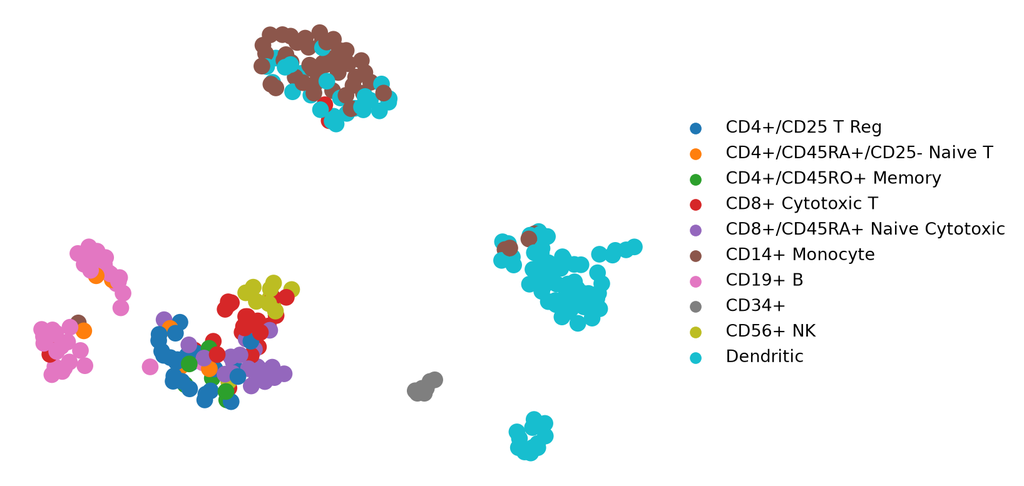

Figure 1: 下采样细胞的 UMAP，按细胞类型着色

```python
ax = sc.pl.umap(a1, color="bulk_labels", show=False, frameon=False, title="")
```

### 6.3 正文里的数字不要手抄

下面这句话里的数字全部由代码实时算出（Quarto ≥ 1.4 支持行内 Python 表达式）：下采样后共有 300 个细胞，分属 10 个类型，其中最多的是 Dendritic（105 个）。详见 Table 1 和 Figure 1。

源码里这句话写的是 `` `{python} n_cells` ``，而不是”300”。**手抄的数字在参数一变时就会和图表脱节**；行内表达式保证正文、表、图三处永远是同一个数。

## 7 用参数重新渲染

参数块里的值可以在渲染时覆盖，不改源文件：

```bash
quarto render quarto_python_reproducible_report_tutorial_20261119.qmd \
  -P seed:7 -P n_subsample:500 --output report_seed7.html
```

Quarto 会在参数块后面插入一个新块，把 `seed`、`n_subsample` 改成新值。用 `--output` 换个文件名，可以避免覆盖原来的报告；这与”修正前先归档旧版”的规矩一致。

**`-P` 依赖 kernel 环境里装有 `papermill`**，没有就报 `The papermill package is required for processing --execute-params`。`sc_tut_main` 已于 2026-11-19 装好 papermill 2.7.0；换别的环境要先确认。本机实测：默认渲染得到 300 个细胞，`-P seed:7 -P n_subsample:500` 得到 500 个细胞，正文数字随之改变。

## 8 渲染命令逐项解释

| 部分 | 作用 |
| --- | --- |
| `QUARTO_PYTHON=.../sc_tut_main/bin/python` | 告诉 Quarto 用哪个 Python 去找 Jupyter 和 kernel |
| `mamba run -p /mnt/ex_8T_SSD/conda_envs/sc_tut_r` | 本机 Quarto（1.9.38）装在 `sc_tut_r` 环境里，必须在激活该环境后才能运行（激活脚本会设好 `QUARTO_DENO`、`QUARTO_PANDOC` 等变量） |
| `quarto render x.qmd` | 跑全部代码块，生成 `x.html` |
| `quarto preview x.qmd` | 边改边看，保存即自动重渲染 |

**Note本机已知的两个坑**

1. **直接执行 `/mnt/ex_8T_SSD/conda_envs/sc_tut_r/bin/quarto` 会报找不到 `deno`**：没有激活环境，缺少 `QUARTO_DENO` 这些变量。必须通过 `mamba run -p` 或先 `mamba activate`。
2. **`conda run -n sc_tut_r` 会报环境不存在**：这个环境没有登记在默认的 envs 目录下，要用 `-p` 加完整路径。

## 9 与 `.ipynb`、Jupytext 互转

```bash
quarto convert analysis.ipynb      # → analysis.qmd（丢弃已存的输出）
quarto convert analysis.qmd        # → analysis.ipynb（未执行）
```

已经习惯 Jupyter 的话，也可以用 Jupytext 把 `.ipynb` 配对成 `.py`，再用 Quarto 渲染 `.ipynb` 本身（`quarto render x.ipynb --execute`）。但 **`.qmd` 作为唯一源文件**是最干净的做法：只有一份文本，没有”哪份是最新”的问题。

## 10 多章节教程：project 与 freeze

单个文件够用到十几个代码块。章节多了，就在目录下放一个 `_quarto.yml`，变成 Quarto project（本机 R 教程 proj23 就是这么组织的）：

```yaml
project:
  type: website          # 或 book
  execute-dir: project   # 所有章节的工作目录统一为项目根，相对路径不随文件位置漂移
execute:
  freeze: auto           # 源文件没变的章节不重跑，直接用 _freeze/ 里的结果
```

`freeze: auto` 只在 project 里生效。它让大型教程不必每次全部重跑；但**改了上游数据、源文件却没变时，结果不会更新**，这种时候要手动 `quarto render --cache-refresh` 或删掉对应 `_freeze/` 子目录（删之前按规矩先确认）。

## 11 可复现报告的检查清单

| 检查项 | 做法 |
| --- | --- |
| 环境 | YAML 里写死 kernel；报告里打印 `sys.executable` 和关键包版本 |
| 随机性 | 种子集中在参数块；非零；关键步骤同参数跑两遍断言一致 |
| 数据路径 | 用绝对路径，或 project 里统一 `execute-dir: project` |
| 正文数字 | 一律用 `` `{python} expr` ``，不手抄 |
| 输出 | `embed-resources: true` 单文件；改参数重渲染用 `--output` 换名，不覆盖旧版 |
| 源文件 | 只提交 `.qmd`；`*.html`、`_freeze/`、`.quarto/` 是构建产物 |

## 12 Session info

```
渲染时间: 2026-11-19 23:11
Python  : 3.11.16  (/mnt/ex_8T_SSD/conda_envs/sc_tut_main/bin/python)
平台    : Linux-6.8.0-124-generic-x86_64-with-glibc2.35
```